# Background

In a Stroop task, participants are presented with a list of words, with each word displayed in a color of ink. The participant’s task is to say out loud the color of the ink in which the word is printed. The task has two conditions: a congruent words condition, and an incongruent words condition. In the congruent words condition, the words being displayed are color words whose names match the colors in which they are printed. In the incongruent words condition, the words displayed are color words whose names do not match the colors in which they are printed. In each case, we measure the time it takes to name the ink colors in equally-sized lists. Each participant will go through and record a time from each condition.

# Questions

1) What is our independent variable? What is our dependent variable?

> - Indepedent variable: word-list condition
> - Dependent variable: time it takes to name the ink colors

2) What is an appropriate set of hypotheses for this task? What kind of statistical test do you expect to perform? Justify your choices.

> - Null Hypothesis ($H_0$): The population mean time it takes to name the ink colors is the same for both congruent ($\mu_0$) and incongruent ($\mu_1$) words conditions.
> - Alternative Hypothesis ($H_1$): The population mean time it takes to name the ink colors is NOT the same for congruent ($\mu_0$) and incongruent ($\mu_1$) words conditions.
> - $H_0 : \mu_0 = \mu_1$
> - $H_1 : \mu_0 \neq \mu_1$

> Because this experiment is matched in pairs (congruent and incongruent), and the sample distribution generally follow a normal distribution, and the sample size is below 30, and the popluation standard deviation is unknown, and we are trying to tell the whether the difference between the two groups exists, I would use the two-tailed paired samples t-test.

3) Report some descriptive statistics regarding this dataset. Include at least one measure of central tendency and at least one measure of variability.

```r
data <- read.csv('stroopdata.csv')
summary(data)
sd(data$Congruent)
sd(data$Incongruent)
```

```
   Congruent      Incongruent
 Min.   : 8.63   Min.   :15.69
 1st Qu.:11.90   1st Qu.:18.72
 Median :14.36   Median :21.02
 Mean   :14.05   Mean   :22.02
 3rd Qu.:16.20   3rd Qu.:24.05
 Max.   :22.33   Max.   :35.26
```

3.5593579576452

4.79705712246914

From the descriptive statistics, we can see the means of `Congruent` and `Incongruent` are about 14 and 22, respectively, the standard deviations are about 3.56 and 4.80, respectively.

4) Provide one or two visualizations that show the distribution of the sample data. Write one or two sentences noting what you observe about the plot or plots.

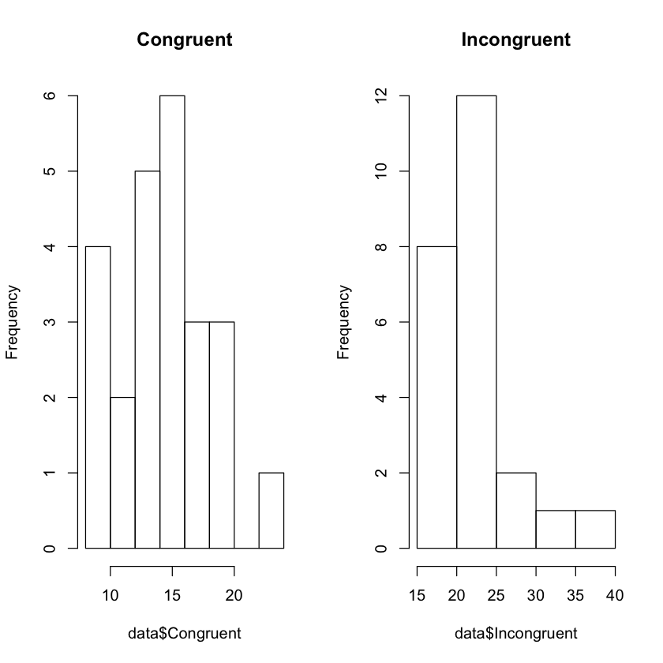

```r
options(jupyter.plot_mimetypes = 'image/png')
par(mfrow=c(1,2))
hist(data$Congruent, main='Congruent')
hist(data$Incongruent, main='Incongruent')
```

From the histogram, we can see that the distribution of the two groups are different, and it seems that the mean of the `Congruent` is less than that of the `Incongruent`.

5) Now, perform the statistical test and report your results. What is your confidence level and your critical statistic value? Do you reject the null hypothesis or fail to reject it? Come to a conclusion in terms of the experiment task. Did the results match up with your expectations?

```r
t.test(data$Congruent, data$Incongruent, paired=TRUE)
```

```
	Paired t-test

data:  data$Congruent and data$Incongruent
t = -8.0207, df = 23, p-value = 4.103e-08
alternative hypothesis: true difference in means is not equal to 0
95 percent confidence interval:
 -10.019028  -5.910555
sample estimates:
mean of the differences
              -7.964792
```

Because p-value is much less than 0.05, we reject the null hypothesis, and consider the `Congruent` and `Incongruent` groups have signiciant difference on the time it takes to read the ink colors. The result matches up with my expectations.